# P6

Luis Domínguez

2024-04-25

## Práctica 6

En el aula virtual se encuentra el archivo `prac6b.csv`.

### (1) Inspección de Xt

**a)** Carga en R los datos del archivo. Los datos contienen una serie de tiempo. Llama a esta serie de tiempo `Xt`.

```r
Xt <- read_csv("./prac6b.csv")
Xt <- as.ts(Xt)
```

**b)** Supongamos que ya sabes que `Xt` es una serie de tiempo estacionaria. Calcula la ACF y la PACF para `Xt`. ¿Cuántos valores significativos tiene la ACF? ¿Cuántos valores significativos tiene la PACF?

[figure not shown]

```r
acfXt <- acf(Xt)
```

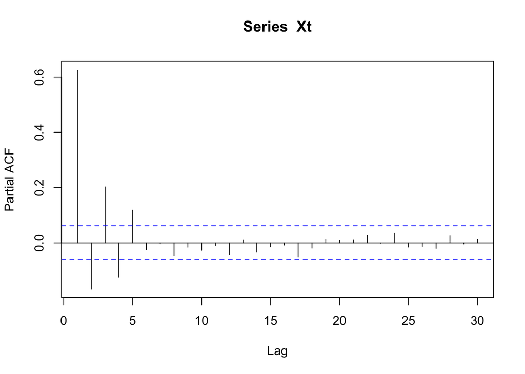

```r
pacfXt <- pacf(Xt)
```

```r
acfXt
```

```
##
## Autocorrelations of series 'Xt', by lag
##
##      0      1      2      3      4      5      6      7      8      9     10
##  1.000  0.625  0.289  0.227  0.138  0.103  0.104  0.062  0.011 -0.020 -0.040
##     11     12     13     14     15     16     17     18     19     20     21
## -0.048 -0.064 -0.063 -0.064 -0.074 -0.069 -0.083 -0.100 -0.076 -0.045 -0.027
##     22     23     24     25     26     27     28     29     30
##  0.002  0.015  0.027  0.032  0.016  0.002  0.014  0.026  0.029
```

```r
pacfXt
```

```
##
## Partial autocorrelations of series 'Xt', by lag
##
##      1      2      3      4      5      6      7      8      9     10     11
##  0.625 -0.167  0.203 -0.125  0.118 -0.024 -0.003 -0.047 -0.015 -0.027 -0.009
##     12     13     14     15     16     17     18     19     20     21     22
## -0.043  0.010 -0.033 -0.014 -0.008 -0.052 -0.019  0.011  0.008  0.010  0.027
##     23     24     25     26     27     28     29     30
## -0.001  0.035 -0.015 -0.013 -0.020  0.026 -0.004  0.012
```

**c)** Realiza una inspección visual, discute con tus compañeros qué valores podrían usarse como máximos `p`, `d`, `q`, para probar distintos candidatos en modelos ARIMA(`p`, `d`, `q`).

### (2) Candidatos para el modelo de Xt

Calcula los coeficientes AIC y BIC para varios candidatos ARIMA(`p`, `d`, `q`). Puedes utilizar el ciclo `for` visto en clase. Para fines prácticos, utiliza un máximo de 3 para `p`, un máximo de 3 para `q` y un máximo de 0 para `d`, puesto que es estacionaria.

```r
P<-3
D<-0
Q<-3
tabla<-data.frame()
for(p in 0:P){
  for(d in 0:D){
    for(q in 0:Q){
      modelo<-arima(Xt,order=c(p,d,q))
      AIC<-AIC(modelo)
      sbic<-AIC(modelo,k=log(length(Xt)))
      tabla<-rbind(tabla,c(p,d,q,AIC,sbic))
    }
  }
}
tabla<-rename(tabla, 'p'=1,'d'=2,'q'=3,'AIC'=4,'sbic'=5)
tabla<-tabla[order(tabla$AIC),]
# tabla<-tabla[order(tabla$sbic),]
tabla
```

```
##    p d q      AIC     sbic
## 14 3 0 1 2853.163 2882.610
## 8  1 0 3 2853.808 2883.255
## 11 2 0 2 2853.872 2883.318
## 7  1 0 2 2854.229 2878.768
## 15 3 0 2 2854.920 2889.275
## 12 2 0 3 2855.793 2890.147
## 16 3 0 3 2856.915 2896.177
## 10 2 0 1 2857.781 2882.319
## 4  0 0 3 2866.148 2890.687
## 6  1 0 1 2874.878 2894.509
## 13 3 0 0 2879.259 2903.797
## 3  0 0 2 2887.151 2906.782
## 2  0 0 1 2909.761 2924.484
## 9  2 0 0 2919.172 2938.803
## 5  1 0 0 2945.527 2960.250
## 1  0 0 0 3439.267 3449.083
```

**a)** Realiza una gráfica con los valores de AIC para los distintos modelos calculados.

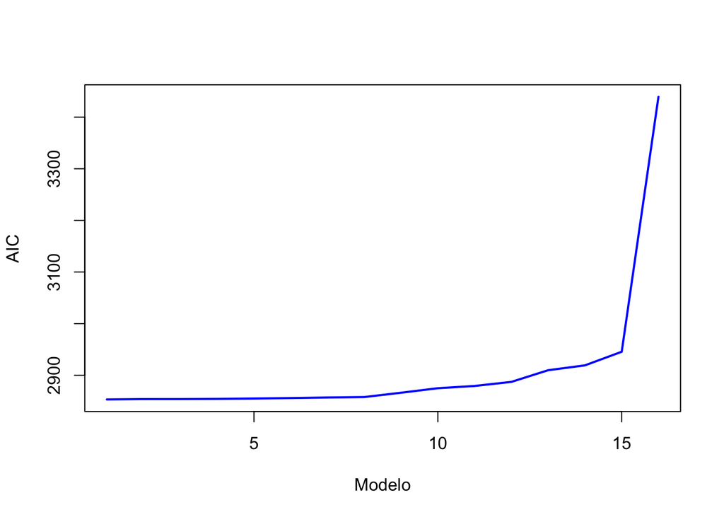

```r
plot(tabla$AIC, type="l", col="blue", lwd=2, xlab="Modelo", ylab="AIC")
```

**b)** Realiza una gráfica con los valores de BIC para los distintos modelos calculados.

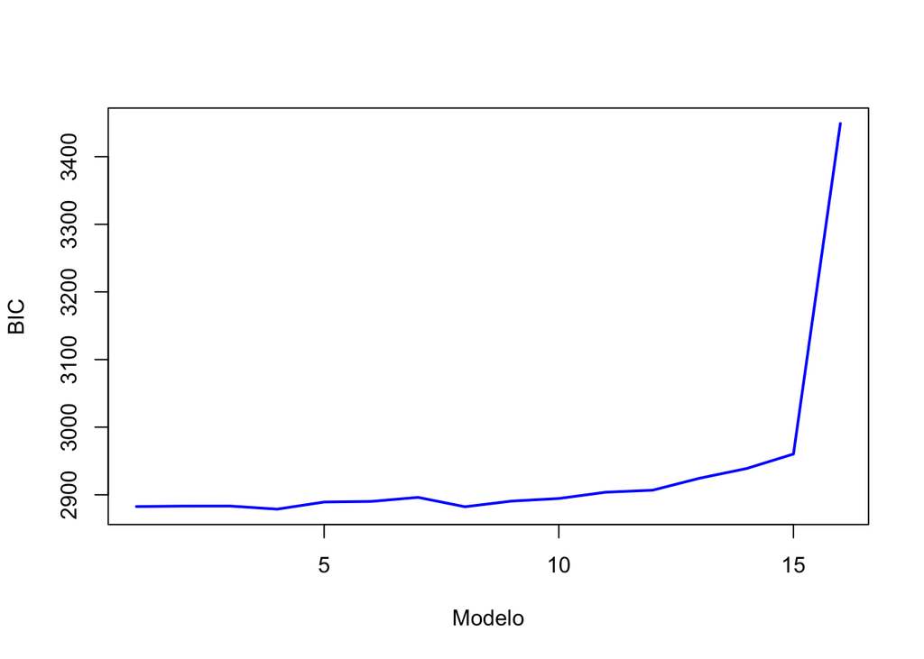

```r
plot(tabla$sbic, type="l", col="blue", lwd=2, xlab="Modelo", ylab="BIC")
```

**c)** ¿Cuál es el mejor candidato de acuerdo a AIC?

El mejor candidato de acuerdo a AIC es el modelo ARIMA(3,0,1).

**d)** ¿Cuál es el mejor candidato de acuerdo a BIC?

```r
tabla<-tabla[order(tabla$sbic),]
tabla
```

```
##    p d q      AIC     sbic
## 7  1 0 2 2854.229 2878.768
## 10 2 0 1 2857.781 2882.319
## 14 3 0 1 2853.163 2882.610
## 8  1 0 3 2853.808 2883.255
## 11 2 0 2 2853.872 2883.318
## 15 3 0 2 2854.920 2889.275
## 12 2 0 3 2855.793 2890.147
## 4  0 0 3 2866.148 2890.687
## 6  1 0 1 2874.878 2894.509
## 16 3 0 3 2856.915 2896.177
## 13 3 0 0 2879.259 2903.797
## 3  0 0 2 2887.151 2906.782
## 2  0 0 1 2909.761 2924.484
## 9  2 0 0 2919.172 2938.803
## 5  1 0 0 2945.527 2960.250
## 1  0 0 0 3439.267 3449.083
```

El mejor candidato de acuerdo a BIC es el modelo ARIMA(1,0,2).

**e)** ¿Cuál es el segundo mejor candidato de acuerdo a AIC?

(1,0,3)

**f)** ¿Cuál es el segundo mejor candidato de acuerdo a BIC?

(2,0,1)

**Nota:** Con la instrucción: `tabla <- tabla[order(tabla$AIC), ]` R ordenará la tabla de acuerdo a la columna AIC.

**g)** Determina la significancia de los coeficientes estimados para el mejor candidato de acuerdo a AIC.

```r
modelo<-arima(Xt,order=c(3,0,1))
summary(modelo)
```

```
##
## Call:
## arima(x = Xt, order = c(3, 0, 1))
##
## Coefficients:
##          ar1     ar2     ar3     ma1  intercept
##       0.1762  0.1111  0.1080  0.6305     0.0176
## s.e.  0.0784  0.0689  0.0407  0.0744     0.0852
##
## sigma^2 estimated as 1.002:  log likelihood = -1420.58,  aic = 2853.16
##
## Training set error measures:
##                         ME     RMSE       MAE      MPE     MAPE      MASE
## Training set -0.0001673722 1.001241 0.8090632 37.42528 191.7465 0.8604493
##                    ACF1
## Training set 0.00148459
```